# create_figuretable

Suguru Otani

2022/12/03

# Estimation

## linear-demand linear-cost

- Demand equation:

$$P_t=\alpha_0-\alpha_1 Q_t-\alpha_2 Z_t Q_t+\alpha_3 Y_t+\varepsilon_{d t}$$

- Optimality equation:

$$P_t=\gamma_0+\theta\left(\hat{\alpha}_1+\hat{\alpha}_2 Z_t\right) \hat{Q}_t+\gamma_1 \hat{Q}_t+\gamma_2 w_t+\gamma_3 r_t+\varepsilon_{c t}$$

- Exogenous variables

$$w \sim N(3,1), r \sim N(0,1), Z \sim N(10,1),Y \sim N(10,1)$$

- Instrumental variables for supply side with_demand_shifter model

$$w_{iv}=w + N(0,1), r_{iv}= r + N(0,1), Y \sim N(10,1)$$

- Instrumental variables for supply side without_demand_shifter model

$$w_{iv}=w + N(0,1), r_{iv}= r + N(0,1)$$

- Parameters

$$\alpha_1=\alpha_2=\alpha_3=\gamma_0=\gamma_1=\gamma_2=\gamma_3=1, \alpha_0=10, \theta=0.5$$

- Errors

$$\varepsilon_{c t} \sim N\left(0, \sigma_d\right), \varepsilon_{d t} \sim N\left(0, \sigma_c\right), \text { and } \sigma=\sigma_d=\sigma_c$$

- DGP

To generate simulation data, we need to obtain the aggregate quantity $Q_t$. From the supply equation and the demand equation, we have

$$\alpha_0-\left[\alpha_1+\alpha_2 Z_t\right] Q_t+\varepsilon_{d t}=\gamma_0+\left[\theta\left(\alpha_1+\alpha_2 Z_t\right)+\gamma_1\right] Q+\gamma_2 w_t+\gamma_3 r_t+\varepsilon_{c t},$$

which gives us the aggregate quantity $Q_t$ as

$$Q_t=\frac{\alpha_0+\alpha_3 Y_t-\gamma_0-\gamma_2 w_t-\gamma_3 r_t+\left(\varepsilon_{d t}-\varepsilon_{c t}\right)}{(1+\theta)\left(\alpha_1+\alpha_2 Z_t\right)+\gamma_1}$$

The price $P_t$ is given by substituting $Q_t$ into the demand equationship.

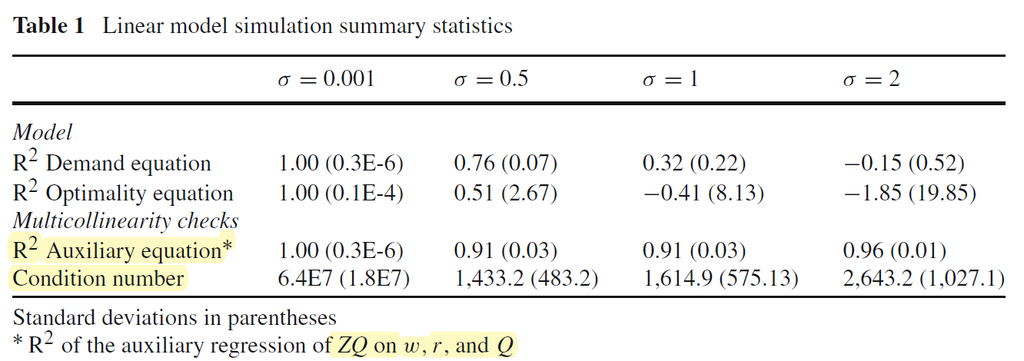

perloff_and_shen2012_table1

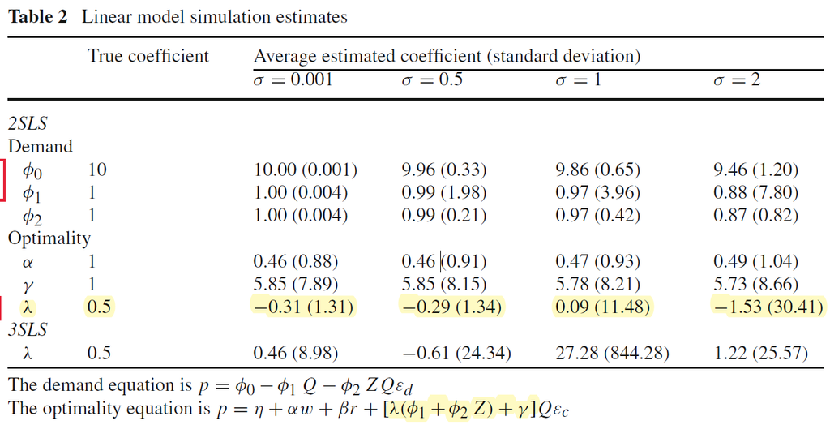

perloff_and_shen2012_table2

### $\sigma = 0.001$

#### $n = 50$

with demand shifter y

|  | Unique (#) | Missing (%) | Mean | SD | Min | Median | Max |  |
| --- | --- | --- | --- | --- | --- | --- | --- | --- |
| group_id_k | 1000 | 0 | 500.500 | 288.819 | 1.000 | 500.500 | 1000.000 |  |
| alpha0_hat | 1000 | 0 | 10.000 | 0.001 | 9.997 | 10.000 | 10.003 |  |
| alpha1_hat | 1000 | 0 | 1.000 | 0.004 | 0.986 | 1.000 | 1.017 |  |
| alpha2_hat | 1000 | 0 | 1.000 | 0.000 | 0.998 | 1.000 | 1.002 |  |
| alpha3_hat | 1000 | 0 | 1.000 | 0.000 | 0.999 | 1.000 | 1.001 |  |
| gamma0_hat | 1000 | 0 | 1.000 | 0.001 | 0.995 | 1.000 | 1.005 |  |
| gamma1_hat | 1000 | 0 | 1.000 | 0.005 | 0.980 | 1.000 | 1.027 |  |
| gamma2_hat | 1000 | 0 | 1.000 | 0.000 | 0.999 | 1.000 | 1.001 |  |
| gamma3_hat | 1000 | 0 | 1.000 | 0.000 | 0.999 | 1.000 | 1.001 |  |
| theta_hat | 1000 | 0 | 0.500 | 0.001 | 0.498 | 0.500 | 0.502 |  |
| R2_demand | 1000 | 0 | 1.000 | 0.000 | 1.000 | 1.000 | 1.000 |  |
| R2_supply | 1000 | 0 | 1.000 | 0.000 | 1.000 | 1.000 | 1.000 |  |

without demand shifter y

|  | Unique (#) | Missing (%) | Mean | SD | Min | Median | Max |  |
| --- | --- | --- | --- | --- | --- | --- | --- | --- |
| group_id_k | 1000 | 0 | 500.500 | 288.819 | 1.000 | 500.500 | 1000.000 |  |
| alpha0_hat | 1000 | 0 | 10.000 | 0.001 | 9.995 | 10.000 | 10.004 |  |
| alpha1_hat | 1000 | 0 | 1.000 | 0.005 | 0.985 | 1.000 | 1.016 |  |
| alpha2_hat | 1000 | 0 | 1.000 | 0.000 | 0.998 | 1.000 | 1.002 |  |
| gamma0_hat | 1000 | 0 | 5.390 | 9.800 | －89.135 | 5.238 | 164.110 |  |
| gamma1_hat | 1000 | 0 | 0.512 | 1.087 | －17.046 | 0.528 | 10.926 |  |
| gamma2_hat | 1000 | 0 | 0.512 | 1.089 | －17.126 | 0.529 | 11.017 |  |
| gamma3_hat | 1000 | 0 | 0.512 | 1.089 | －17.127 | 0.529 | 11.012 |  |
| theta_hat | 1000 | 0 | －0.232 | 1.634 | －26.693 | －0.206 | 15.529 |  |
| R2_demand | 1000 | 0 | 1.000 | 0.000 | 1.000 | 1.000 | 1.000 |  |
| R2_supply | 1000 | 0 | 1.000 | 0.000 | 0.999 | 1.000 | 1.000 |  |

#### $n = 100$

with demand shifter y

|  | Unique (#) | Missing (%) | Mean | SD | Min | Median | Max |  |
| --- | --- | --- | --- | --- | --- | --- | --- | --- |
| group_id_k | 1000 | 0 | 500.500 | 288.819 | 1.000 | 500.500 | 1000.000 |  |
| alpha0_hat | 1000 | 0 | 10.000 | 0.001 | 9.998 | 10.000 | 10.002 |  |
| alpha1_hat | 1000 | 0 | 1.000 | 0.003 | 0.991 | 1.000 | 1.010 |  |
| alpha2_hat | 1000 | 0 | 1.000 | 0.000 | 0.999 | 1.000 | 1.001 |  |
| alpha3_hat | 1000 | 0 | 1.000 | 0.000 | 1.000 | 1.000 | 1.000 |  |
| gamma0_hat | 1000 | 0 | 1.000 | 0.001 | 0.996 | 1.000 | 1.003 |  |
| gamma1_hat | 1000 | 0 | 1.000 | 0.004 | 0.988 | 1.000 | 1.012 |  |
| gamma2_hat | 1000 | 0 | 1.000 | 0.000 | 1.000 | 1.000 | 1.000 |  |
| gamma3_hat | 1000 | 0 | 1.000 | 0.000 | 1.000 | 1.000 | 1.001 |  |
| theta_hat | 1000 | 0 | 0.500 | 0.000 | 0.499 | 0.500 | 0.501 |  |
| R2_demand | 1000 | 0 | 1.000 | 0.000 | 1.000 | 1.000 | 1.000 |  |
| R2_supply | 1000 | 0 | 1.000 | 0.000 | 1.000 | 1.000 | 1.000 |  |

without demand shifter y

|  | Unique (#) | Missing (%) | Mean | SD | Min | Median | Max |  |
| --- | --- | --- | --- | --- | --- | --- | --- | --- |
| group_id_k | 1000 | 0 | 500.500 | 288.819 | 1.000 | 500.500 | 1000.000 |  |
| alpha0_hat | 1000 | 0 | 10.000 | 0.001 | 9.998 | 10.000 | 10.002 |  |
| alpha1_hat | 1000 | 0 | 1.000 | 0.003 | 0.990 | 1.000 | 1.010 |  |
| alpha2_hat | 1000 | 0 | 1.000 | 0.000 | 0.999 | 1.000 | 1.001 |  |
| gamma0_hat | 1000 | 0 | 5.547 | 8.543 | －83.152 | 5.710 | 81.018 |  |
| gamma1_hat | 1000 | 0 | 0.495 | 0.949 | －7.859 | 0.476 | 10.341 |  |
| gamma2_hat | 1000 | 0 | 0.495 | 0.949 | －7.892 | 0.477 | 10.350 |  |
| gamma3_hat | 1000 | 0 | 0.495 | 0.949 | －7.891 | 0.477 | 10.349 |  |
| theta_hat | 1000 | 0 | －0.258 | 1.424 | －12.841 | －0.285 | 14.524 |  |
| R2_demand | 1000 | 0 | 1.000 | 0.000 | 1.000 | 1.000 | 1.000 |  |
| R2_supply | 1000 | 0 | 1.000 | 0.000 | 1.000 | 1.000 | 1.000 |  |

#### $n = 200$

with demand shifter y

|  | Unique (#) | Missing (%) | Mean | SD | Min | Median | Max |  |
| --- | --- | --- | --- | --- | --- | --- | --- | --- |
| group_id_k | 1000 | 0 | 500.500 | 288.819 | 1.000 | 500.500 | 1000.000 |  |
| alpha0_hat | 1000 | 0 | 10.000 | 0.000 | 9.999 | 10.000 | 10.002 |  |
| alpha1_hat | 1000 | 0 | 1.000 | 0.002 | 0.992 | 1.000 | 1.007 |  |
| alpha2_hat | 1000 | 0 | 1.000 | 0.000 | 0.999 | 1.000 | 1.001 |  |
| alpha3_hat | 1000 | 0 | 1.000 | 0.000 | 1.000 | 1.000 | 1.000 |  |
| gamma0_hat | 1000 | 0 | 1.000 | 0.001 | 0.998 | 1.000 | 1.002 |  |
| gamma1_hat | 1000 | 0 | 1.000 | 0.002 | 0.991 | 1.000 | 1.007 |  |
| gamma2_hat | 1000 | 0 | 1.000 | 0.000 | 1.000 | 1.000 | 1.000 |  |
| gamma3_hat | 1000 | 0 | 1.000 | 0.000 | 1.000 | 1.000 | 1.000 |  |
| theta_hat | 1000 | 0 | 0.500 | 0.000 | 0.499 | 0.500 | 0.501 |  |
| R2_demand | 1000 | 0 | 1.000 | 0.000 | 1.000 | 1.000 | 1.000 |  |
| R2_supply | 1000 | 0 | 1.000 | 0.000 | 1.000 | 1.000 | 1.000 |  |

without demand shifter y

|  | Unique (#) | Missing (%) | Mean | SD | Min | Median | Max |  |
| --- | --- | --- | --- | --- | --- | --- | --- | --- |
| group_id_k | 1000 | 0 | 500.500 | 288.819 | 1.000 | 500.500 | 1000.000 |  |
| alpha0_hat | 1000 | 0 | 10.000 | 0.000 | 9.998 | 10.000 | 10.001 |  |
| alpha1_hat | 1000 | 0 | 1.000 | 0.002 | 0.993 | 1.000 | 1.006 |  |
| alpha2_hat | 1000 | 0 | 1.000 | 0.000 | 0.999 | 1.000 | 1.001 |  |
| gamma0_hat | 1000 | 0 | 5.623 | 7.771 | －53.247 | 5.562 | 104.207 |  |
| gamma1_hat | 1000 | 0 | 0.486 | 0.864 | －10.503 | 0.494 | 7.017 |  |
| gamma2_hat | 1000 | 0 | 0.486 | 0.863 | －10.468 | 0.493 | 7.027 |  |
| gamma3_hat | 1000 | 0 | 0.486 | 0.863 | －10.464 | 0.493 | 7.027 |  |
| theta_hat | 1000 | 0 | －0.270 | 1.295 | －16.697 | －0.260 | 9.540 |  |
| R2_demand | 1000 | 0 | 1.000 | 0.000 | 1.000 | 1.000 | 1.000 |  |
| R2_supply | 1000 | 0 | 1.000 | 0.000 | 1.000 | 1.000 | 1.000 |  |

#### $n = 1000$

with demand shifter y

|  | Unique (#) | Missing (%) | Mean | SD | Min | Median | Max |  |
| --- | --- | --- | --- | --- | --- | --- | --- | --- |
| group_id_k | 1000 | 0 | 500.500 | 288.819 | 1.000 | 500.500 | 1000.000 |  |
| alpha0_hat | 1000 | 0 | 10.000 | 0.000 | 9.999 | 10.000 | 10.001 |  |
| alpha1_hat | 1000 | 0 | 1.000 | 0.001 | 0.997 | 1.000 | 1.003 |  |
| alpha2_hat | 1000 | 0 | 1.000 | 0.000 | 1.000 | 1.000 | 1.000 |  |
| alpha3_hat | 1000 | 0 | 1.000 | 0.000 | 1.000 | 1.000 | 1.000 |  |
| gamma0_hat | 1000 | 0 | 1.000 | 0.000 | 0.999 | 1.000 | 1.001 |  |
| gamma1_hat | 1000 | 0 | 1.000 | 0.001 | 0.997 | 1.000 | 1.004 |  |
| gamma2_hat | 1000 | 0 | 1.000 | 0.000 | 1.000 | 1.000 | 1.000 |  |
| gamma3_hat | 1000 | 0 | 1.000 | 0.000 | 1.000 | 1.000 | 1.000 |  |
| theta_hat | 1000 | 0 | 0.500 | 0.000 | 0.500 | 0.500 | 0.500 |  |
| R2_demand | 1000 | 0 | 1.000 | 0.000 | 1.000 | 1.000 | 1.000 |  |
| R2_supply | 1000 | 0 | 1.000 | 0.000 | 1.000 | 1.000 | 1.000 |  |

without demand shifter y

|  | Unique (#) | Missing (%) | Mean | SD | Min | Median | Max |  |
| --- | --- | --- | --- | --- | --- | --- | --- | --- |
| group_id_k | 1000 | 0 | 500.500 | 288.819 | 1.000 | 500.500 | 1000.000 |  |
| alpha0_hat | 1000 | 0 | 10.000 | 0.000 | 9.999 | 10.000 | 10.001 |  |
| alpha1_hat | 1000 | 0 | 1.000 | 0.001 | 0.997 | 1.000 | 1.003 |  |
| alpha2_hat | 1000 | 0 | 1.000 | 0.000 | 1.000 | 1.000 | 1.000 |  |
| gamma0_hat | 1000 | 0 | 5.579 | 9.298 | －83.345 | 5.533 | 84.921 |  |
| gamma1_hat | 1000 | 0 | 0.491 | 1.033 | －8.320 | 0.496 | 10.371 |  |
| gamma2_hat | 1000 | 0 | 0.491 | 1.033 | －8.324 | 0.496 | 10.372 |  |
| gamma3_hat | 1000 | 0 | 0.491 | 1.033 | －8.324 | 0.496 | 10.372 |  |
| theta_hat | 1000 | 0 | －0.263 | 1.550 | －13.487 | －0.256 | 14.558 |  |
| R2_demand | 1000 | 0 | 1.000 | 0.000 | 1.000 | 1.000 | 1.000 |  |
| R2_supply | 1000 | 0 | 1.000 | 0.000 | 1.000 | 1.000 | 1.000 |  |

### $\sigma = 0.5$

#### $n = 50$

with demand shifter y

|  | Unique (#) | Missing (%) | Mean | SD | Min | Median | Max |  |
| --- | --- | --- | --- | --- | --- | --- | --- | --- |
| group_id_k | 1000 | 0 | 500.500 | 288.819 | 1.000 | 500.500 | 1000.000 |  |
| alpha0_hat | 1000 | 0 | 9.982 | 0.465 | 8.548 | 9.945 | 12.188 |  |
| alpha1_hat | 1000 | 0 | 0.955 | 2.257 | －6.367 | 1.006 | 12.173 |  |
| alpha2_hat | 1000 | 0 | 0.999 | 0.255 | 0.103 | 0.990 | 2.005 |  |
| alpha3_hat | 1000 | 0 | 0.995 | 0.108 | 0.642 | 0.989 | 1.652 |  |
| gamma0_hat | 1000 | 0 | 0.939 | 0.730 | －2.262 | 1.015 | 2.918 |  |
| gamma1_hat | 1000 | 0 | 0.689 | 3.438 | －44.599 | 1.052 | 9.412 |  |
| gamma2_hat | 1000 | 0 | 1.009 | 0.109 | 0.702 | 1.000 | 1.504 |  |
| gamma3_hat | 1000 | 0 | 1.001 | 0.108 | 0.671 | 0.998 | 1.464 |  |
| theta_hat | 1000 | 0 | 0.547 | 0.351 | －0.346 | 0.500 | 5.083 |  |
| R2_demand | 1000 | 0 | 0.762 | 0.083 | 0.161 | 0.774 | 0.923 |  |
| R2_supply | 1000 | 0 | 0.768 | 0.075 | 0.478 | 0.776 | 0.916 |  |

without demand shifter y

|  | Unique (#) | Missing (%) | Mean | SD | Min | Median | Max |  |
| --- | --- | --- | --- | --- | --- | --- | --- | --- |
| group_id_k | 1000 | 0 | 500.500 | 288.819 | 1.000 | 500.500 | 1000.000 |  |
| alpha0_hat | 1000 | 0 | 10.013 | 0.472 | 8.783 | 9.983 | 12.555 |  |
| alpha1_hat | 1000 | 0 | 0.986 | 2.124 | －6.201 | 0.978 | 7.635 |  |
| alpha2_hat | 1000 | 0 | 1.005 | 0.250 | 0.279 | 0.997 | 1.935 |  |
| gamma0_hat | 1000 | 0 | 5.096 | 8.725 | －109.402 | 5.665 | 54.164 |  |
| gamma1_hat | 1000 | 0 | 0.359 | 5.148 | －119.000 | 0.314 | 40.688 |  |
| gamma2_hat | 1000 | 0 | 0.544 | 0.958 | －4.779 | 0.485 | 13.086 |  |
| gamma3_hat | 1000 | 0 | 0.545 | 0.941 | －5.286 | 0.482 | 11.507 |  |
| theta_hat | 1000 | 0 | －0.165 | 1.731 | －9.344 | －0.254 | 30.575 |  |
| R2_demand | 1000 | 0 | 0.718 | 0.098 | 0.199 | 0.737 | 0.903 |  |
| R2_supply | 1000 | 0 | 0.347 | 3.854 | －74.514 | 0.819 | 0.950 |  |

#### $n = 100$

with demand shifter y

|  | Unique (#) | Missing (%) | Mean | SD | Min | Median | Max |  |
| --- | --- | --- | --- | --- | --- | --- | --- | --- |
| group_id_k | 1000 | 0 | 500.500 | 288.819 | 1.000 | 500.500 | 1000.000 |  |
| alpha0_hat | 1000 | 0 | 10.007 | 0.323 | 9.183 | 9.988 | 11.320 |  |
| alpha1_hat | 1000 | 0 | 1.024 | 1.523 | －4.634 | 1.017 | 5.832 |  |
| alpha2_hat | 1000 | 0 | 0.999 | 0.176 | 0.395 | 0.991 | 1.717 |  |
| alpha3_hat | 1000 | 0 | 1.003 | 0.075 | 0.789 | 0.997 | 1.291 |  |
| gamma0_hat | 1000 | 0 | 0.995 | 0.474 | －0.791 | 1.030 | 2.452 |  |
| gamma1_hat | 1000 | 0 | 0.876 | 1.925 | －7.106 | 1.007 | 7.044 |  |
| gamma2_hat | 1000 | 0 | 0.999 | 0.071 | 0.795 | 0.994 | 1.226 |  |
| gamma3_hat | 1000 | 0 | 1.003 | 0.075 | 0.745 | 1.001 | 1.360 |  |
| theta_hat | 1000 | 0 | 0.517 | 0.208 | 0.000 | 0.495 | 1.450 |  |
| R2_demand | 1000 | 0 | 0.763 | 0.057 | 0.430 | 0.770 | 0.896 |  |
| R2_supply | 1000 | 0 | 0.768 | 0.050 | 0.496 | 0.772 | 0.894 |  |

without demand shifter y

|  | Unique (#) | Missing (%) | Mean | SD | Min | Median | Max |  |
| --- | --- | --- | --- | --- | --- | --- | --- | --- |
| group_id_k | 1000 | 0 | 500.500 | 288.819 | 1.000 | 500.500 | 1000.000 |  |
| alpha0_hat | 1000 | 0 | 10.003 | 0.327 | 8.880 | 9.993 | 11.770 |  |
| alpha1_hat | 1000 | 0 | 1.109 | 1.511 | －3.640 | 1.074 | 6.849 |  |
| alpha2_hat | 1000 | 0 | 0.990 | 0.172 | 0.460 | 0.991 | 1.639 |  |
| gamma0_hat | 1000 | 0 | 8.479 | 101.977 | －274.086 | 5.565 | 3207.097 |  |
| gamma1_hat | 1000 | 0 | 1.312 | 29.498 | －28.359 | 0.250 | 930.454 |  |
| gamma2_hat | 1000 | 0 | 0.157 | 11.776 | －369.369 | 0.491 | 31.998 |  |
| gamma3_hat | 1000 | 0 | 0.200 | 10.344 | －323.595 | 0.490 | 33.230 |  |
| theta_hat | 1000 | 0 | －0.837 | 20.176 | －634.652 | －0.262 | 50.732 |  |
| R2_demand | 1000 | 0 | 0.725 | 0.064 | 0.277 | 0.735 | 0.854 |  |
| R2_supply | 1000 | 0 | －59.217 | 1872.776 | －59220.768 | 0.818 | 0.916 |  |

#### $n = 200$

with demand shifter y

|  | Unique (#) | Missing (%) | Mean | SD | Min | Median | Max |  |
| --- | --- | --- | --- | --- | --- | --- | --- | --- |
| group_id_k | 1000 | 0 | 500.500 | 288.819 | 1.000 | 500.500 | 1000.000 |  |
| alpha0_hat | 1000 | 0 | 9.992 | 0.213 | 9.364 | 9.992 | 10.712 |  |
| alpha1_hat | 1000 | 0 | 1.018 | 1.016 | －2.643 | 0.992 | 4.679 |  |
| alpha2_hat | 1000 | 0 | 0.996 | 0.115 | 0.663 | 0.994 | 1.412 |  |
| alpha3_hat | 1000 | 0 | 0.999 | 0.050 | 0.847 | 1.000 | 1.194 |  |
| gamma0_hat | 1000 | 0 | 0.979 | 0.345 | －0.277 | 0.994 | 2.041 |  |
| gamma1_hat | 1000 | 0 | 0.919 | 1.302 | －4.237 | 0.986 | 4.967 |  |
| gamma2_hat | 1000 | 0 | 1.003 | 0.051 | 0.835 | 0.999 | 1.171 |  |
| gamma3_hat | 1000 | 0 | 1.003 | 0.052 | 0.856 | 1.000 | 1.215 |  |
| theta_hat | 1000 | 0 | 0.514 | 0.134 | 0.118 | 0.507 | 1.014 |  |
| R2_demand | 1000 | 0 | 0.765 | 0.036 | 0.637 | 0.769 | 0.846 |  |
| R2_supply | 1000 | 0 | 0.766 | 0.035 | 0.644 | 0.769 | 0.872 |  |

without demand shifter y

|  | Unique (#) | Missing (%) | Mean | SD | Min | Median | Max |  |
| --- | --- | --- | --- | --- | --- | --- | --- | --- |
| group_id_k | 1000 | 0 | 500.500 | 288.819 | 1.000 | 500.500 | 1000.000 |  |
| alpha0_hat | 1000 | 0 | 10.007 | 0.226 | 9.349 | 10.002 | 10.915 |  |
| alpha1_hat | 1000 | 0 | 1.028 | 0.999 | －1.904 | 1.044 | 4.809 |  |
| alpha2_hat | 1000 | 0 | 0.999 | 0.117 | 0.677 | 0.998 | 1.492 |  |
| gamma0_hat | 1000 | 0 | 5.481 | 7.497 | －39.117 | 5.618 | 88.028 |  |
| gamma1_hat | 1000 | 0 | 0.452 | 1.386 | －7.770 | 0.345 | 13.476 |  |
| gamma2_hat | 1000 | 0 | 0.502 | 0.835 | －8.826 | 0.482 | 5.642 |  |
| gamma3_hat | 1000 | 0 | 0.505 | 0.829 | －8.002 | 0.486 | 5.672 |  |
| theta_hat | 1000 | 0 | －0.242 | 1.261 | －14.681 | －0.260 | 7.778 |  |
| R2_demand | 1000 | 0 | 0.727 | 0.042 | 0.533 | 0.732 | 0.824 |  |
| R2_supply | 1000 | 0 | 0.508 | 1.659 | －38.780 | 0.820 | 0.906 |  |

#### $n = 1000$

with demand shifter y

|  | Unique (#) | Missing (%) | Mean | SD | Min | Median | Max |  |
| --- | --- | --- | --- | --- | --- | --- | --- | --- |
| group_id_k | 1000 | 0 | 500.500 | 288.819 | 1.000 | 500.500 | 1000.000 |  |
| alpha0_hat | 1000 | 0 | 9.994 | 0.097 | 9.706 | 9.993 | 10.328 |  |
| alpha1_hat | 1000 | 0 | 0.969 | 0.454 | －0.488 | 0.974 | 2.305 |  |
| alpha2_hat | 1000 | 0 | 1.001 | 0.051 | 0.859 | 1.000 | 1.173 |  |
| alpha3_hat | 1000 | 0 | 0.999 | 0.022 | 0.934 | 0.998 | 1.073 |  |
| gamma0_hat | 1000 | 0 | 0.995 | 0.152 | 0.461 | 1.002 | 1.497 |  |
| gamma1_hat | 1000 | 0 | 0.997 | 0.548 | －0.572 | 1.011 | 2.516 |  |
| gamma2_hat | 1000 | 0 | 1.000 | 0.023 | 0.936 | 0.999 | 1.086 |  |
| gamma3_hat | 1000 | 0 | 1.000 | 0.022 | 0.920 | 1.000 | 1.061 |  |
| theta_hat | 1000 | 0 | 0.503 | 0.058 | 0.311 | 0.500 | 0.656 |  |
| R2_demand | 1000 | 0 | 0.764 | 0.016 | 0.697 | 0.765 | 0.805 |  |
| R2_supply | 1000 | 0 | 0.763 | 0.016 | 0.706 | 0.764 | 0.813 |  |

without demand shifter y

|  | Unique (#) | Missing (%) | Mean | SD | Min | Median | Max |  |
| --- | --- | --- | --- | --- | --- | --- | --- | --- |
| group_id_k | 1000 | 0 | 500.500 | 288.819 | 1.000 | 500.500 | 1000.000 |  |
| alpha0_hat | 1000 | 0 | 9.996 | 0.095 | 9.691 | 9.991 | 10.310 |  |
| alpha1_hat | 1000 | 0 | 1.013 | 0.458 | －0.466 | 1.018 | 2.527 |  |
| alpha2_hat | 1000 | 0 | 0.998 | 0.051 | 0.845 | 0.997 | 1.157 |  |
| gamma0_hat | 1000 | 0 | 6.172 | 12.256 | －92.537 | 5.617 | 187.807 |  |
| gamma1_hat | 1000 | 0 | 0.457 | 1.188 | －14.179 | 0.380 | 12.904 |  |
| gamma2_hat | 1000 | 0 | 0.426 | 1.373 | －20.361 | 0.484 | 11.570 |  |
| gamma3_hat | 1000 | 0 | 0.425 | 1.359 | －19.133 | 0.485 | 11.156 |  |
| theta_hat | 1000 | 0 | －0.365 | 2.083 | －31.688 | －0.276 | 16.737 |  |
| R2_demand | 1000 | 0 | 0.729 | 0.018 | 0.641 | 0.729 | 0.780 |  |
| R2_supply | 1000 | 0 | －0.129 | 9.163 | －212.821 | 0.818 | 0.886 |  |

### $\sigma = 1$

#### $n = 50$

with demand shifter y

|  | Unique (#) | Missing (%) | Mean | SD | Min | Median | Max |  |
| --- | --- | --- | --- | --- | --- | --- | --- | --- |
| group_id_k | 1000 | 0 | 500.500 | 288.819 | 1.000 | 500.500 | 1000.000 |  |
| alpha0_hat | 1000 | 0 | 9.973 | 1.023 | 7.669 | 9.852 | 22.166 |  |
| alpha1_hat | 1000 | 0 | 0.976 | 4.398 | －11.783 | 0.883 | 17.787 |  |
| alpha2_hat | 1000 | 0 | 0.994 | 0.495 | －0.538 | 0.969 | 3.658 |  |
| alpha3_hat | 1000 | 0 | 0.994 | 0.223 | 0.410 | 0.975 | 2.508 |  |
| gamma0_hat | 1000 | 0 | 0.682 | 1.741 | －12.430 | 0.987 | 4.236 |  |
| gamma1_hat | 1000 | 0 | 6.859 | 210.877 | －309.269 | 1.758 | 6621.525 |  |
| gamma2_hat | 1000 | 0 | 1.035 | 0.244 | 0.508 | 1.012 | 2.656 |  |
| gamma3_hat | 1000 | 0 | 1.045 | 0.246 | 0.465 | 1.013 | 2.736 |  |
| theta_hat | 1000 | 0 | 0.101 | 18.455 | －575.510 | 0.470 | 38.144 |  |
| R2_demand | 1000 | 0 | 0.301 | 0.409 | －8.735 | 0.379 | 0.748 |  |
| R2_supply | 1000 | 0 | 0.267 | 0.369 | －4.587 | 0.352 | 0.726 |  |

without demand shifter y

|  | Unique (#) | Missing (%) | Mean | SD | Min | Median | Max |  |
| --- | --- | --- | --- | --- | --- | --- | --- | --- |
| group_id_k | 1000 | 0 | 500.500 | 288.819 | 1.000 | 500.500 | 1000.000 |  |
| alpha0_hat | 1000 | 0 | 9.894 | 0.968 | 7.284 | 9.807 | 18.186 |  |
| alpha1_hat | 1000 | 0 | 1.062 | 4.523 | －13.048 | 0.849 | 38.448 |  |
| alpha2_hat | 1000 | 0 | 0.965 | 0.502 | －1.530 | 0.954 | 4.557 |  |
| gamma0_hat | 1000 | 0 | 5.560 | 18.940 | －125.002 | 5.289 | 542.968 |  |
| gamma1_hat | 1000 | 0 | －1.395 | 38.899 | －816.965 | 0.397 | 474.603 |  |
| gamma2_hat | 1000 | 0 | 0.491 | 2.126 | －59.697 | 0.506 | 14.288 |  |
| gamma3_hat | 1000 | 0 | 0.485 | 2.300 | －65.623 | 0.528 | 17.708 |  |
| theta_hat | 1000 | 0 | －0.030 | 5.423 | －75.788 | －0.274 | 120.545 |  |
| R2_demand | 1000 | 0 | 0.223 | 0.357 | －3.505 | 0.310 | 0.784 |  |
| R2_supply | 1000 | 0 | －3.600 | 91.339 | －2833.005 | 0.523 | 0.814 |  |

#### $n = 100$

with demand shifter y

|  | Unique (#) | Missing (%) | Mean | SD | Min | Median | Max |  |
| --- | --- | --- | --- | --- | --- | --- | --- | --- |
| group_id_k | 1000 | 0 | 500.500 | 288.819 | 1.000 | 500.500 | 1000.000 |  |
| alpha0_hat | 1000 | 0 | 9.998 | 0.641 | 8.119 | 9.945 | 13.039 |  |
| alpha1_hat | 1000 | 0 | 0.831 | 2.962 | －8.941 | 0.700 | 15.120 |  |
| alpha2_hat | 1000 | 0 | 1.016 | 0.324 | 0.028 | 1.005 | 2.358 |  |
| alpha3_hat | 1000 | 0 | 1.002 | 0.153 | 0.640 | 0.993 | 1.785 |  |
| gamma0_hat | 1000 | 0 | 0.909 | 1.055 | －4.037 | 1.031 | 3.479 |  |
| gamma1_hat | 1000 | 0 | 0.321 | 6.247 | －116.344 | 1.158 | 20.894 |  |
| gamma2_hat | 1000 | 0 | 1.011 | 0.157 | 0.626 | 0.994 | 1.756 |  |
| gamma3_hat | 1000 | 0 | 1.012 | 0.150 | 0.600 | 1.001 | 1.661 |  |
| theta_hat | 1000 | 0 | 0.598 | 0.732 | －0.892 | 0.484 | 15.870 |  |
| R2_demand | 1000 | 0 | 0.305 | 0.199 | －0.826 | 0.350 | 0.625 |  |
| R2_supply | 1000 | 0 | 0.308 | 0.186 | －0.851 | 0.338 | 0.654 |  |

without demand shifter y

|  | Unique (#) | Missing (%) | Mean | SD | Min | Median | Max |  |
| --- | --- | --- | --- | --- | --- | --- | --- | --- |
| group_id_k | 1000 | 0 | 500.500 | 288.819 | 1.000 | 500.500 | 1000.000 |  |
| alpha0_hat | 1000 | 0 | 10.002 | 0.628 | 8.257 | 9.930 | 13.380 |  |
| alpha1_hat | 1000 | 0 | 1.030 | 2.972 | －7.979 | 1.007 | 11.790 |  |
| alpha2_hat | 1000 | 0 | 0.998 | 0.335 | 0.101 | 0.969 | 2.100 |  |
| gamma0_hat | 1000 | 0 | 7.167 | 50.076 | －92.245 | 5.520 | 1570.678 |  |
| gamma1_hat | 1000 | 0 | －0.431 | 11.789 | －332.681 | 0.231 | 20.994 |  |
| gamma2_hat | 1000 | 0 | 0.279 | 6.606 | －206.655 | 0.498 | 11.110 |  |
| gamma3_hat | 1000 | 0 | 0.315 | 5.712 | －178.148 | 0.505 | 11.466 |  |
| theta_hat | 1000 | 0 | －0.532 | 10.506 | －328.102 | －0.263 | 31.104 |  |
| R2_demand | 1000 | 0 | 0.226 | 0.215 | －1.313 | 0.265 | 0.602 |  |
| R2_supply | 1000 | 0 | －33.578 | 1050.645 | －33223.991 | 0.509 | 0.746 |  |

#### $n = 200$

with demand shifter y

|  | Unique (#) | Missing (%) | Mean | SD | Min | Median | Max |  |
| --- | --- | --- | --- | --- | --- | --- | --- | --- |
| group_id_k | 1000 | 0 | 500.500 | 288.819 | 1.000 | 500.500 | 1000.000 |  |
| alpha0_hat | 1000 | 0 | 9.996 | 0.448 | 8.893 | 9.963 | 11.950 |  |
| alpha1_hat | 1000 | 0 | 1.061 | 2.060 | －5.248 | 0.988 | 7.480 |  |
| alpha2_hat | 1000 | 0 | 0.993 | 0.234 | 0.386 | 0.982 | 1.834 |  |
| alpha3_hat | 1000 | 0 | 0.999 | 0.099 | 0.724 | 0.995 | 1.397 |  |
| gamma0_hat | 1000 | 0 | 0.914 | 0.709 | －2.279 | 0.972 | 2.747 |  |
| gamma1_hat | 1000 | 0 | 0.662 | 2.954 | －12.778 | 0.923 | 9.485 |  |
| gamma2_hat | 1000 | 0 | 1.011 | 0.103 | 0.737 | 1.007 | 1.500 |  |
| gamma3_hat | 1000 | 0 | 1.010 | 0.104 | 0.678 | 1.007 | 1.416 |  |
| theta_hat | 1000 | 0 | 0.554 | 0.303 | －0.183 | 0.521 | 1.847 |  |
| R2_demand | 1000 | 0 | 0.310 | 0.134 | －0.365 | 0.332 | 0.582 |  |
| R2_supply | 1000 | 0 | 0.306 | 0.128 | －0.251 | 0.323 | 0.602 |  |

without demand shifter y

|  | Unique (#) | Missing (%) | Mean | SD | Min | Median | Max |  |
| --- | --- | --- | --- | --- | --- | --- | --- | --- |
| group_id_k | 1000 | 0 | 500.500 | 288.819 | 1.000 | 500.500 | 1000.000 |  |
| alpha0_hat | 1000 | 0 | 9.975 | 0.445 | 8.823 | 9.955 | 11.785 |  |
| alpha1_hat | 1000 | 0 | 1.052 | 2.080 | －6.864 | 1.018 | 7.367 |  |
| alpha2_hat | 1000 | 0 | 0.988 | 0.231 | 0.274 | 0.974 | 1.889 |  |
| gamma0_hat | 1000 | 0 | 5.428 | 7.124 | －44.552 | 5.395 | 70.018 |  |
| gamma1_hat | 1000 | 0 | 0.357 | 3.041 | －36.490 | 0.297 | 22.082 |  |
| gamma2_hat | 1000 | 0 | 0.509 | 0.800 | －6.940 | 0.513 | 6.138 |  |
| gamma3_hat | 1000 | 0 | 0.500 | 0.801 | －7.453 | 0.508 | 6.005 |  |
| theta_hat | 1000 | 0 | －0.231 | 1.238 | －9.694 | －0.263 | 10.066 |  |
| R2_demand | 1000 | 0 | 0.240 | 0.144 | －0.692 | 0.262 | 0.569 |  |
| R2_supply | 1000 | 0 | －0.294 | 3.584 | －64.101 | 0.499 | 0.733 |  |

#### $n = 1000$

with demand shifter y

|  | Unique (#) | Missing (%) | Mean | SD | Min | Median | Max |  |
| --- | --- | --- | --- | --- | --- | --- | --- | --- |
| group_id_k | 1000 | 0 | 500.500 | 288.819 | 1.000 | 500.500 | 1000.000 |  |
| alpha0_hat | 1000 | 0 | 9.984 | 0.187 | 9.409 | 9.980 | 10.581 |  |
| alpha1_hat | 1000 | 0 | 1.011 | 0.905 | －1.814 | 1.040 | 4.851 |  |
| alpha2_hat | 1000 | 0 | 0.994 | 0.100 | 0.684 | 0.993 | 1.308 |  |
| alpha3_hat | 1000 | 0 | 0.997 | 0.045 | 0.853 | 0.995 | 1.136 |  |
| gamma0_hat | 1000 | 0 | 0.996 | 0.308 | －0.169 | 1.010 | 1.942 |  |
| gamma1_hat | 1000 | 0 | 0.950 | 1.109 | －3.044 | 0.988 | 4.265 |  |
| gamma2_hat | 1000 | 0 | 1.000 | 0.045 | 0.878 | 0.998 | 1.159 |  |
| gamma3_hat | 1000 | 0 | 1.002 | 0.045 | 0.860 | 1.001 | 1.143 |  |
| theta_hat | 1000 | 0 | 0.509 | 0.113 | 0.184 | 0.504 | 0.909 |  |
| R2_demand | 1000 | 0 | 0.319 | 0.054 | 0.078 | 0.322 | 0.454 |  |
| R2_supply | 1000 | 0 | 0.315 | 0.052 | 0.152 | 0.315 | 0.465 |  |

without demand shifter y

|  | Unique (#) | Missing (%) | Mean | SD | Min | Median | Max |  |
| --- | --- | --- | --- | --- | --- | --- | --- | --- |
| group_id_k | 1000 | 0 | 500.500 | 288.819 | 1.000 | 500.500 | 1000.000 |  |
| alpha0_hat | 1000 | 0 | 9.993 | 0.194 | 9.515 | 9.988 | 10.766 |  |
| alpha1_hat | 1000 | 0 | 1.026 | 0.946 | －2.135 | 1.009 | 4.144 |  |
| alpha2_hat | 1000 | 0 | 0.995 | 0.106 | 0.682 | 0.993 | 1.373 |  |
| gamma0_hat | 1000 | 0 | 4.970 | 8.330 | －96.306 | 5.307 | 52.025 |  |
| gamma1_hat | 1000 | 0 | 0.555 | 1.441 | －5.528 | 0.343 | 19.067 |  |
| gamma2_hat | 1000 | 0 | 0.559 | 0.930 | －4.658 | 0.522 | 12.051 |  |
| gamma3_hat | 1000 | 0 | 0.556 | 0.927 | －4.640 | 0.517 | 12.230 |  |
| theta_hat | 1000 | 0 | －0.159 | 1.408 | －8.624 | －0.220 | 16.997 |  |
| R2_demand | 1000 | 0 | 0.244 | 0.061 | －0.001 | 0.252 | 0.430 |  |
| R2_supply | 1000 | 0 | －0.691 | 9.474 | －198.961 | 0.498 | 0.665 |  |

### $\sigma = 2$

#### $n = 50$

with demand shifter y

|  | Unique (#) | Missing (%) | Mean | SD | Min | Median | Max |  |
| --- | --- | --- | --- | --- | --- | --- | --- | --- |
| group_id_k | 1000 | 0 | 500.500 | 288.819 | 1.000 | 500.500 | 1000.000 |  |
| alpha0_hat | 1000 | 0 | 9.737 | 2.584 | －12.149 | 9.453 | 37.354 |  |
| alpha1_hat | 1000 | 0 | 0.729 | 10.822 | －83.527 | 0.254 | 127.922 |  |
| alpha2_hat | 1000 | 0 | 0.956 | 1.253 | －7.701 | 0.872 | 18.834 |  |
| alpha3_hat | 1000 | 0 | 0.976 | 0.584 | －2.588 | 0.898 | 9.990 |  |
| gamma0_hat | 1000 | 0 | －1.074 | 19.523 | －364.774 | 1.035 | 70.591 |  |
| gamma1_hat | 1000 | 0 | 59.209 | 1750.596 | －1504.065 | 3.493 | 55219.802 |  |
| gamma2_hat | 1000 | 0 | 1.242 | 2.420 | －8.420 | 0.994 | 50.301 |  |
| gamma3_hat | 1000 | 0 | 1.230 | 2.318 | －9.466 | 0.984 | 47.627 |  |
| theta_hat | 1000 | 0 | －6.168 | 233.873 | －7333.892 | 0.212 | 690.257 |  |
| R2_demand | 1000 | 0 | －0.653 | 3.934 | －104.028 | －0.044 | 0.560 |  |
| R2_supply | 1000 | 0 | －10.545 | 132.912 | －3289.518 | －0.207 | 0.643 |  |

without demand shifter y

|  | Unique (#) | Missing (%) | Mean | SD | Min | Median | Max |  |
| --- | --- | --- | --- | --- | --- | --- | --- | --- |
| group_id_k | 1000 | 0 | 500.500 | 288.819 | 1.000 | 500.500 | 1000.000 |  |
| alpha0_hat | 1000 | 0 | 9.782 | 2.698 | －17.727 | 9.461 | 30.414 |  |
| alpha1_hat | 1000 | 0 | 1.165 | 10.522 | －45.333 | 0.903 | 91.569 |  |
| alpha2_hat | 1000 | 0 | 0.922 | 1.281 | －10.524 | 0.857 | 9.745 |  |
| gamma0_hat | 1000 | 0 | 5.434 | 7.013 | －41.108 | 5.636 | 74.855 |  |
| gamma1_hat | 1000 | 0 | 17.792 | 411.574 | －647.880 | 0.895 | 12869.824 |  |
| gamma2_hat | 1000 | 0 | 0.505 | 0.816 | －6.752 | 0.483 | 5.770 |  |
| gamma3_hat | 1000 | 0 | 0.506 | 0.982 | －12.054 | 0.498 | 8.215 |  |
| theta_hat | 1000 | 0 | －2.020 | 40.804 | －1274.157 | －0.504 | 67.182 |  |
| R2_demand | 1000 | 0 | －0.809 | 3.300 | －55.491 | －0.136 | 0.553 |  |
| R2_supply | 1000 | 0 | －1.164 | 8.732 | －179.698 | 0.123 | 0.641 |  |

#### $n = 100$

with demand shifter y

|  | Unique (#) | Missing (%) | Mean | SD | Min | Median | Max |  |
| --- | --- | --- | --- | --- | --- | --- | --- | --- |
| group_id_k | 1000 | 0 | 500.500 | 288.819 | 1.000 | 500.500 | 1000.000 |  |
| alpha0_hat | 1000 | 0 | 10.071 | 1.669 | 6.397 | 9.804 | 22.014 |  |
| alpha1_hat | 1000 | 0 | 1.008 | 6.495 | －35.003 | 0.896 | 29.350 |  |
| alpha2_hat | 1000 | 0 | 1.023 | 0.779 | －0.965 | 0.952 | 7.914 |  |
| alpha3_hat | 1000 | 0 | 1.008 | 0.343 | 0.210 | 0.967 | 3.305 |  |
| gamma0_hat | 1000 | 0 | 0.449 | 2.994 | －26.794 | 0.970 | 6.109 |  |
| gamma1_hat | 1000 | 0 | －1.416 | 56.886 | －1028.310 | 1.511 | 683.529 |  |
| gamma2_hat | 1000 | 0 | 1.065 | 0.404 | 0.154 | 1.008 | 4.472 |  |
| gamma3_hat | 1000 | 0 | 1.055 | 0.400 | 0.296 | 1.000 | 4.648 |  |
| theta_hat | 1000 | 0 | 0.872 | 6.326 | －60.865 | 0.462 | 137.378 |  |
| R2_demand | 1000 | 0 | －0.513 | 1.300 | －14.358 | －0.182 | 0.441 |  |
| R2_supply | 1000 | 0 | －0.670 | 1.930 | －35.157 | －0.269 | 0.446 |  |

without demand shifter y

|  | Unique (#) | Missing (%) | Mean | SD | Min | Median | Max |  |
| --- | --- | --- | --- | --- | --- | --- | --- | --- |
| group_id_k | 1000 | 0 | 500.500 | 288.819 | 1.000 | 500.500 | 1000.000 |  |
| alpha0_hat | 1000 | 0 | 9.971 | 1.402 | 6.744 | 9.737 | 18.179 |  |
| alpha1_hat | 1000 | 0 | 1.522 | 6.139 | －25.459 | 1.191 | 25.709 |  |
| alpha2_hat | 1000 | 0 | 0.943 | 0.663 | －1.242 | 0.928 | 5.316 |  |
| gamma0_hat | 1000 | 0 | 5.410 | 10.482 | －73.267 | 5.641 | 212.479 |  |
| gamma1_hat | 1000 | 0 | 6.725 | 143.004 | －695.023 | 0.347 | 3885.298 |  |
| gamma2_hat | 1000 | 0 | 0.508 | 1.157 | －23.571 | 0.480 | 8.089 |  |
| gamma3_hat | 1000 | 0 | 0.518 | 1.204 | －20.453 | 0.503 | 9.862 |  |
| theta_hat | 1000 | 0 | －1.106 | 16.826 | －442.656 | －0.337 | 29.870 |  |
| R2_demand | 1000 | 0 | －0.492 | 0.923 | －10.663 | －0.233 | 0.375 |  |
| R2_supply | 1000 | 0 | －3.358 | 42.760 | －1267.507 | 0.109 | 0.516 |  |

#### $n = 200$

with demand shifter y

|  | Unique (#) | Missing (%) | Mean | SD | Min | Median | Max |  |
| --- | --- | --- | --- | --- | --- | --- | --- | --- |
| group_id_k | 1000 | 0 | 500.500 | 288.819 | 1.000 | 500.500 | 1000.000 |  |
| alpha0_hat | 1000 | 0 | 9.960 | 0.947 | 7.683 | 9.853 | 14.903 |  |
| alpha1_hat | 1000 | 0 | 1.236 | 4.259 | －14.676 | 1.046 | 20.518 |  |
| alpha2_hat | 1000 | 0 | 0.969 | 0.482 | －0.678 | 0.933 | 3.687 |  |
| alpha3_hat | 1000 | 0 | 0.996 | 0.225 | 0.404 | 0.969 | 2.389 |  |
| gamma0_hat | 1000 | 0 | 0.829 | 1.507 | －8.959 | 1.036 | 4.133 |  |
| gamma1_hat | 1000 | 0 | －2.617 | 38.895 | －1002.209 | 1.015 | 177.250 |  |
| gamma2_hat | 1000 | 0 | 1.020 | 0.219 | 0.510 | 0.997 | 2.352 |  |
| gamma3_hat | 1000 | 0 | 1.010 | 0.219 | 0.368 | 0.982 | 2.234 |  |
| theta_hat | 1000 | 0 | 0.918 | 3.799 | －21.759 | 0.506 | 89.591 |  |
| R2_demand | 1000 | 0 | －0.363 | 0.518 | －6.063 | －0.241 | 0.286 |  |
| R2_supply | 1000 | 0 | －0.401 | 0.505 | －6.137 | －0.290 | 0.330 |  |

without demand shifter y

|  | Unique (#) | Missing (%) | Mean | SD | Min | Median | Max |  |
| --- | --- | --- | --- | --- | --- | --- | --- | --- |
| group_id_k | 1000 | 0 | 500.500 | 288.819 | 1.000 | 500.500 | 1000.000 |  |
| alpha0_hat | 1000 | 0 | 10.043 | 1.126 | 7.698 | 9.900 | 26.674 |  |
| alpha1_hat | 1000 | 0 | 0.976 | 4.394 | －15.587 | 0.952 | 14.742 |  |
| alpha2_hat | 1000 | 0 | 1.017 | 0.541 | －0.283 | 0.958 | 6.494 |  |
| gamma0_hat | 1000 | 0 | 5.444 | 8.725 | －112.453 | 5.624 | 46.282 |  |
| gamma1_hat | 1000 | 0 | －0.703 | 15.951 | －229.066 | 0.164 | 171.910 |  |
| gamma2_hat | 1000 | 0 | 0.509 | 1.018 | －4.978 | 0.484 | 13.945 |  |
| gamma3_hat | 1000 | 0 | 0.499 | 0.986 | －4.779 | 0.483 | 11.210 |  |
| theta_hat | 1000 | 0 | －0.121 | 2.553 | －27.192 | －0.293 | 37.336 |  |
| R2_demand | 1000 | 0 | －0.490 | 1.406 | －41.291 | －0.307 | 0.264 |  |
| R2_supply | 1000 | 0 | －2.069 | 15.706 | －394.084 | 0.092 | 0.472 |  |

#### $n = 1000$

with demand shifter y

|  | Unique (#) | Missing (%) | Mean | SD | Min | Median | Max |  |
| --- | --- | --- | --- | --- | --- | --- | --- | --- |
| group_id_k | 1000 | 0 | 500.500 | 288.819 | 1.000 | 500.500 | 1000.000 |  |
| alpha0_hat | 1000 | 0 | 9.998 | 0.412 | 8.948 | 9.970 | 11.330 |  |
| alpha1_hat | 1000 | 0 | 1.021 | 1.810 | －5.420 | 0.969 | 5.912 |  |
| alpha2_hat | 1000 | 0 | 0.997 | 0.210 | 0.360 | 0.998 | 1.856 |  |
| alpha3_hat | 1000 | 0 | 1.003 | 0.092 | 0.733 | 0.999 | 1.360 |  |
| gamma0_hat | 1000 | 0 | 0.949 | 0.631 | －1.426 | 0.996 | 2.783 |  |
| gamma1_hat | 1000 | 0 | 0.897 | 2.333 | －9.601 | 1.126 | 8.272 |  |
| gamma2_hat | 1000 | 0 | 1.006 | 0.093 | 0.714 | 1.004 | 1.345 |  |
| gamma3_hat | 1000 | 0 | 1.008 | 0.092 | 0.771 | 0.997 | 1.293 |  |
| theta_hat | 1000 | 0 | 0.524 | 0.244 | －0.250 | 0.505 | 1.822 |  |
| R2_demand | 1000 | 0 | －0.319 | 0.191 | －1.021 | －0.297 | 0.050 |  |
| R2_supply | 1000 | 0 | －0.326 | 0.174 | －1.056 | －0.311 | 0.096 |  |

without demand shifter y

|  | Unique (#) | Missing (%) | Mean | SD | Min | Median | Max |  |
| --- | --- | --- | --- | --- | --- | --- | --- | --- |
| group_id_k | 1000 | 0 | 500.500 | 288.819 | 1.000 | 500.500 | 1000.000 |  |
| alpha0_hat | 1000 | 0 | 9.995 | 0.377 | 9.000 | 9.971 | 11.602 |  |
| alpha1_hat | 1000 | 0 | 0.971 | 1.860 | －4.314 | 0.929 | 7.270 |  |
| alpha2_hat | 1000 | 0 | 1.003 | 0.209 | 0.305 | 1.003 | 1.626 |  |
| gamma0_hat | 1000 | 0 | 5.519 | 9.926 | －173.420 | 5.715 | 63.683 |  |
| gamma1_hat | 1000 | 0 | 0.469 | 3.504 | －32.177 | 0.293 | 66.031 |  |
| gamma2_hat | 1000 | 0 | 0.497 | 1.114 | －6.340 | 0.471 | 20.432 |  |
| gamma3_hat | 1000 | 0 | 0.497 | 1.134 | －5.860 | 0.475 | 22.032 |  |
| theta_hat | 1000 | 0 | －0.255 | 1.650 | －8.960 | －0.291 | 25.282 |  |
| R2_demand | 1000 | 0 | －0.381 | 0.178 | －1.157 | －0.350 | －0.014 |  |
| R2_supply | 1000 | 0 | －3.036 | 37.346 | －1088.053 | 0.070 | 0.386 |  |

## log-linear-demand log-linear-cost